# Hotel Booking Analysis

In order to build the model of logistic regression we will use the glm function. The response is represented by is_canceled and the predictors are represented by some independent variables.

We clearly specify that we want a logistic regression by setting the attribute family as “binomial”.

```
##
## Call:
## glm(formula = is_canceled ~ lead_time + customer_type + hotel +
##     deposit_type + adr + total_of_special_requests, family = "binomial",
##     data = mydataset)
##
## Deviance Residuals:
##     Min       1Q   Median       3Q      Max
## -2.9767  -0.8087  -0.5849   0.2038   2.7645
##
## Coefficients:
##                                Estimate Std. Error z value Pr(>|z|)
## (Intercept)                  -1.8814713  0.0475111 -39.601  < 2e-16 ***
## lead_time                     0.0048474  0.0000781  62.066  < 2e-16 ***
## customer_typeGroup           -0.6239389  0.1473791  -4.234 2.30e-05 ***
## customer_typeTransient        0.6274113  0.0445352  14.088  < 2e-16 ***
## customer_typeTransient-Party -0.2813941  0.0466103  -6.037 1.57e-09 ***
## hotelResort Hotel            -0.3099591  0.0152919 -20.270  < 2e-16 ***
## deposit_typeNon Refund        5.1679826  0.1047350  49.343  < 2e-16 ***
## deposit_typeRefundable       -0.0388890  0.1961689  -0.198    0.843
## adr                           0.0048739  0.0001476  33.031  < 2e-16 ***
## total_of_special_requests    -0.5470358  0.0101321 -53.990  < 2e-16 ***
## ---
## Signif. codes:  0 '***' 0.001 '**' 0.01 '*' 0.05 '.' 0.1 ' ' 1
##
## (Dispersion parameter for binomial family taken to be 1)
##
##     Null deviance: 157398  on 119389  degrees of freedom
## Residual deviance: 117225  on 119380  degrees of freedom
## AIC: 117245
##
## Number of Fisher Scoring iterations: 7
```

Summary returns the standard errors, z-score, estimations and p-values for each of the coefficients. According to the results, all coefficients, with one exception, are meaningful.

The next step is to make predictions.

```
## [1] 0.5234317 0.8816891 0.2378428 0.2431552 0.1728522 0.1728522
```

We will get an array of probabilities. The first two probabilities are bigger, measuring aproximatively 50% and 88%. We will compute the accuracy of the model and try to predict whether the bookings will be canceled or not, based on the variables chosen as predictors. In order to do this, we will use the ifelse command and as a threshold we will compute a mean.

Vom obtine un vector de probabilitati. Primele doua probabilitati sunt mai mari, masurand aproximativ 50% si respectiv 88%.

```
## [1] 0.3704163
```

- mydataset predictions is an array of true and false values. If mydataset predict is higher than p, mydataset predictions takes value 1, otherwise, takes value 0.

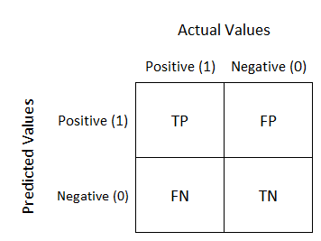

Confusion matrix

TP=true positive TN=true negative FP=false positive FN=false negative

```
##
##         0     1
##   0 62233 17077
##   1 12933 27147
```

```
## [1] 0.7486389
```

The accuracy of the model is almost 75%. According to the confusion matrix, the model predicted correctly that 62233 bookings won’t be canceled, but classified wrong 17077 bookings. By analogy, the model predicted wrong 12933 bookings and classified correctly 27147 bookings as being cancelled.

As a last step, we will analyse two parameters, AUC and ROC, which are used to assess the performance of the classification model. AUC= area under curve ROC= receiver operating characteristics

AUC can tell us whether the model is able to distinguish between the classes. The higher it is, the better the model will predict if the result will be 1 or 0.

```
##
##  C:\Users\catal\AppData\Local\Temp\Rtmpi8zGeU\downloaded_packages
```

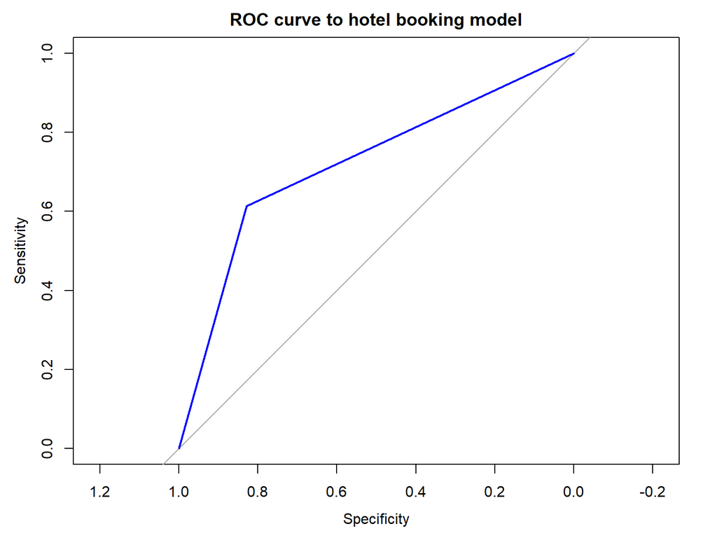

The area under the ROC curve is AUC and is computed as this:

```
## Area under the curve: 0.7209
```

# Conclusions and recommendations